# Homework 03

## Question 1: Build an `explain-to-me` skill

Create a small skill named `explain-to-me` that helps you understand a homework question.

1. Design your `SKILL.md` file so that, when you explicitly ask your agent to use the skill to read a homework question, the agent communicates with you and explains what the question is asking.
2. Keep the skill file short. It should contain a few useful rules, instructions, and a clear statement of your intent. For example, you may ask the agent to explain the goal of the question, clarify what work is required, and point you to an appropriate section of the Week 3 lectures: [Ridge Regression: Stability Through Shrinkage](https://teazrq.github.io/stat432rpy/topics/ridge-regression/ridge-regression.html) or [From a Penalized Objective to a Fitted Ridge Model](https://teazrq.github.io/stat432rpy/topics/ridge-regression/optimization-and-cross-validation.html). The skill should help you understand the question without completing the solution for you.
3. Create the skill yourself or with the help of AI. Save it as `explain-to-me/SKILL.md`. Then ask your AI agent to install the skill using its normal skill-installation method. Test it by explicitly asking the agent to use `explain-to-me` to read and explain Question 2.
4. If the skill does not work well, or if it begins to disturb your usual workflow, ask your agent to remove the installed skill. You may revise and reinstall it if you wish.
5. In all cases, append the complete contents of your developed `explain-to-me/SKILL.md` file at the end of your Homework 3 submission under the heading **`explain-to-me` skill**.

I created the skill and installed it at `.github/skills/explain-to-me/SKILL.md`. I tested it by explicitly asking the agent to use `explain-to-me` to read and explain Question 2. The complete skill file is included at the end of this submission.

## Question 2: Ridge regression with nearly collinear predictors

Let $n=100$. Generate mutually independent standard normal random variables

$$L_i, U_{i1}, U_{i2}, X_{i3}, X_{i4},
\qquad i=1,\ldots,n,$$

and define

$$X_{i1}=L_i+0.04U_{i1},
\qquad
X_{i2}=L_i+0.04U_{i2}.$$

**Show the workflow**

```r
library(tidyverse)
```

**Show the workflow**

```r
set.seed(43231)
```

**Show the workflow**

```r
n = 100
L = rnorm(n)
U1 = rnorm(n)
U2 = rnorm(n)
X3 = rnorm(n)
X4 = rnorm(n)
X1 = L + 0.04*U1
X2 = L + 0.04*U2
```

Center and standardize each column of $\mathbf X$ to have mean zero and average squared value one, following the [lecture’s scaling convention](https://teazrq.github.io/stat432rpy/topics/ridge-regression/ridge-regression.html#put-every-covariate-on-a-common-scale).

**Show the workflow**

```r
X1_avg = mean(X1)
X1_c = X1 - X1_avg
X2_avg = mean(X2)
X2_c = X2 - X2_avg
X3_avg = mean(X3)
X3_c = X3 - X3_avg
X4_avg = mean(X4)
X4_c = X4 - X4_avg

sj_1 = sqrt(sum((X1 - X1_avg)^2)/100)
X1_end = X1_c/sj_1

sj_2 = sqrt(sum((X2 - X2_avg)^2)/100)
X2_end = X2_c/sj_2

sj_3 = sqrt(sum((X3 - X3_avg)^2)/100)
X3_end = X3_c/sj_3

sj_4 = sqrt(sum((X4 - X4_avg)^2)/100)
X4_end = X4_c/sj_4

X = cbind(X1_end, X2_end, X3_end, X4_end)
```

Continue to use $\mathbf X\in\mathbb R^{n\times p}$ for the standardized matrix and keep it fixed throughout the question, where $p=4$ is the number of predictors. The unpenalized intercept gives $p+1=5$ total fitted coefficients. Let

$$\boldsymbol\beta
=
(1.5,1.5,1,0)^{\mathsf T},
\qquad
\boldsymbol\mu
=
\mathbf X\boldsymbol\beta.$$

**Show the workflow**

```r
vec = c(1.5, 1.5, 1,0)
beta = as.matrix(x = vec, nrow = 4, ncol = 1)
mu = X %*% beta
```

Generate a training response and an independent test response at the same predictor values:

$$\begin{aligned}
\mathbf y
&=
\boldsymbol\mu+\boldsymbol\epsilon,\\
\mathbf y^*
&=
\boldsymbol\mu+\boldsymbol\epsilon^*,
\end{aligned}$$

where

$$\boldsymbol\epsilon,
\boldsymbol\epsilon^*
\overset{\mathrm{ind}}{\sim}
\mathcal N_n(\mathbf0,\mathbf I_n).$$

**Show the workflow**

```r
e = rnorm(n)
estar = rnorm(n)

y = mu + e
ystar = mu + estar
```

Center the training response as $\widetilde{\mathbf y}=\mathbf y-\bar y\mathbf1_n$.

**Show the workflow**

```r
ybar = mean(y)
ytilde = y - ybar
```

For each $\lambda\in\{0,0.02,0.2\}$, fit the slopes using the lecture’s ridge formula:

$$\widehat{\boldsymbol\beta}_\lambda
=
\left(\mathbf X^{\mathsf T}\mathbf X+n\lambda\mathbf I_p\right)^{-1}
\mathbf X^{\mathsf T}\widetilde{\mathbf y}.$$

**Show the workflow**

```r
betahat_0 = solve(t(X)%*%X + 0)%*%t(X)%*%ytilde
betahat_0.02 = solve(t(X)%*%X + n*0.02*diag(ncol(X)))%*%t(X)%*%ytilde
betahat_0.20 = solve(t(X)%*%X + n*0.20*diag(ncol(X)))%*%t(X)%*%ytilde
```

The unpenalized intercept is $\widehat\beta_0=\bar y$; add this training mean back when predicting either response. The case $\lambda=0$ is ordinary least squares. Use seed `43231` before generating the design and responses. R and Python use different random-number generators, so their exact numerical results need not agree.

1. Generate $\mathbf X$ once. Report the correlation between its first two columns and its largest and smallest singular values. Use these quantities to explain why the estimator contrast $\widehat\beta_1-\widehat\beta_2$ should be much more variable than $\widehat\beta_1+\widehat\beta_2$.

   **Show the workflow**

   ```r
   cor(X[,1], X[,2])
   ```

   ```
   [1] 0.9977057
   ```

   **Show the workflow**

   ```r
   eigs = eigen(t(X)%*%X)$values
   ```

   **Show the workflow**

   ```r
   sqrt(eigs)
   ```

   ```
   [1] 14.1414804 10.3477319  9.6289673  0.4753575
   ```

   We can see that the first two columns are extremely correlated, with a correlation of 0.998. The largest singular value is also from the first column, while the last column has a very small singular value and doesn’t add that much more information. Adding $\hat\beta_1$ and $\hat\beta_2$ wouldn’t be that variable because the differences between columns would balance out, whereas the direction matters for $\hat\beta_1$ - $\hat\beta_2$ so the results could vary more.
2. Independently repeat the generation of $\mathbf y$ and $\mathbf y^*$, followed by all three fits, 200 times while keeping $\mathbf X$ fixed. Draw the training and test noise inside each repetition, then reuse that realized pair for all three values of $\lambda$. For each value of $\lambda$, report the empirical mean and standard deviation of

$$\widehat\beta_1,
\quad
\widehat\beta_2,
\quad
\widehat\beta_1+\widehat\beta_2,
\quad
\widehat\beta_1-\widehat\beta_2.$$

Also report the average training MSE and the average test MSE calculated from the independent test response, where

$$\operatorname{MSE}_{\mathrm{test}}
=
\frac{1}{n}
\left\lVert
\mathbf y^*
-
\widehat\beta_0\mathbf1_n
-
\mathbf X\widehat{\boldsymbol\beta}
\right\rVert_2^2.$$

**Show the workflow**

```r
results = matrix(NA, nrow = 200, ncol = 12)

colnames(results) = c(
  "b1_0", "b2_0", "sum_0", "diff_0",
  "b1_02", "b2_02", "sum_02", "diff_02",
  "b1_20", "b2_20", "sum_20", "diff_20"
)

mse = matrix(NA, nrow = 200, ncol = 6)

colnames(mse) = c(
  "train_0", "test_0",
  "train_02", "test_02",
  "train_20", "test_20"
)


for (i in 1:200) {
  e = rnorm(n)
  estar = rnorm(n)
  y = mu + e
  ystar = mu + estar
  ybar = mean(y)
  ytilde = y - ybar

  betahat_0 = solve(t(X)%*%X + 0)%*%t(X)%*%ytilde
  betahat_02 = solve(t(X)%*%X + n*0.02*diag(ncol(X)))%*%t(X)%*%ytilde
  betahat_20 = solve(t(X)%*%X + n*0.20*diag(ncol(X)))%*%t(X)%*%ytilde

  results[i, ] = c(
    betahat_0[1],
    betahat_0[2],
    betahat_0[1] + betahat_0[2],
    betahat_0[1] - betahat_0[2],

    betahat_02[1],
    betahat_02[2],
    betahat_02[1] + betahat_02[2],
    betahat_02[1] - betahat_02[2],

    betahat_20[1],
    betahat_20[2],
    betahat_20[1] + betahat_20[2],
    betahat_20[1] - betahat_20[2]
  )

  yhat_0 = mean(y) + X %*% betahat_0
  yhat_02 = mean(y) + X %*% betahat_02
  yhat_20 = mean(y) + X %*% betahat_20

  mse[i, 1] = mean((y - yhat_0)^2)
  mse[i, 3] = mean((y - yhat_02)^2)
  mse[i, 5] = mean((y - yhat_20)^2)

  mse[i, 2] = mean((ystar - yhat_0)^2)
  mse[i, 4] = mean((ystar - yhat_02)^2)
  mse[i, 6] = mean((ystar - yhat_20)^2)
}
```

**Show the workflow**

```r
colMeans(results)
```

```
         b1_0          b2_0         sum_0        diff_0         b1_02
 1.4974255309  1.5074346769  3.0048602078 -0.0100091460  1.4869620341
        b2_02        sum_02       diff_02         b1_20         b2_20
 1.4887203690  2.9756824032 -0.0017583349  1.3677095780  1.3684473587
       sum_20       diff_20
 2.7361569367 -0.0007377806
```

**Show the workflow**

```r
answer = apply(results, 2, sd)
answer
```

```
      b1_0       b2_0      sum_0     diff_0      b1_02      b2_02     sum_02
1.54255454 1.54685122 0.09519986 3.08794161 0.16153881 0.16561036 0.09425647
   diff_02      b1_20      b2_20     sum_20    diff_20
0.31330316 0.04579468 0.04731112 0.08654996 0.03435249
```

**Show the workflow**

```r
colMeans(mse)
```

```
  train_0    test_0  train_02   test_02  train_20   test_20
0.9661721 1.0652633 0.9760795 1.0520183 1.0781792 1.1368255
```

3. Interpret the coefficient estimates and test MSE using bias and variance. Explain why ridge can substantially stabilize the individual coefficients without producing an equally large change in the fitted values.

Solutions:

Singular values do not correspond to a certain column. The smallest singular value represents the direction with the least information, which here is X_1 - X_2. So, small changes can produce large changes in $\hat\beta_1 - \hat\beta_2$ and is less stable.

The fitted values don’t change much because ridge shrinks the unstable component, so since X_1 is approx equal to X2, it doesn’t change the X1 + X2 much.

$\lambda = 0.2$ isn’t worth it because of the increase in bias without too much variance improvement.

## Question 3: What does ridge regression shrink?

Let $\mathbf X\in\mathbb R^{n\times p}$ be a centered predictor matrix, and let $\widetilde{\mathbf y}\in\mathbb R^n$ be the centered response. Use the supplied predictor scales for this algebraic question; the columns need not have unit variance. Here $p$ counts predictors, $\boldsymbol\beta\in\mathbb R^p$ contains their slopes, and $p+1$ counts all fitted coefficients, including the separately fitted, unpenalized intercept. Ridge regression minimizes

$$L_\lambda(\boldsymbol\beta)
=
\frac{1}{2n}
\left\lVert
\widetilde{\mathbf y}-\mathbf X\boldsymbol\beta
\right\rVert_2^2
+
\frac{\lambda}{2}
\lVert\boldsymbol\beta\rVert_2^2.$$

1. Derive the ridge normal equation

$$\left(
\mathbf X^{\mathsf T}\mathbf X
+n\lambda\mathbf I_p
\right)
\widehat{\boldsymbol\beta}_\lambda
=
\mathbf X^{\mathsf T}\widetilde{\mathbf y}.$$

Explain why it has a unique solution whenever $\lambda>0$, even if $\mathbf X$ is rank deficient or $p>n$.

I showed the steps on paper, so they are not all typed out here.

It always has a unique solution because of the penalty term being positive and adding the $n\lambda I_P$.

2. Let

$$\mathbf X
=
\mathbf U_r\mathbf D_r\mathbf V_r^{\mathsf T}$$

be a compact singular value decomposition, where $r=\operatorname{rank}(\mathbf X)$, $\mathbf U_r\in\mathbb R^{n\times r}$, $\mathbf D_r\in\mathbb R^{r\times r}$, and $\mathbf V_r\in\mathbb R^{p\times r}$. Show that ridge multiplies the fitted response component in the $j$th left singular-vector direction, for $j=1,\ldots,r$, by

$$\rho_j(\lambda)
=
\frac{d_j^2}{d_j^2+n\lambda}.$$

Suppose $n=100$, $\lambda=0.01$, and the nonzero singular values are

$$d_1=10,
\qquad
d_2=2,
\qquad
d_3=0.2.$$

Calculate the three shrinkage factors and the total effective degrees of freedom, including the unpenalized intercept:

$$\operatorname{df}_{\mathrm{eff}}(\lambda)
=
1+\sum_{j=1}^3\rho_j(\lambda).$$

The three shrinkage factors:

**Show the workflow**

```r
n = 100
lambda = 0.01
d1 = 10
d2 = 2
d3 = 0.2
factor1 = (d1^2)/(d1^2 + n*lambda)
factor2 = (d2^2)/(d2^2 + n*lambda)
factor3 = (d3^2)/(d3^2 + n*lambda)
factor1
```

```
[1] 0.990099
```

**Show the workflow**

```r
factor2
```

```
[1] 0.8
```

**Show the workflow**

```r
factor3
```

```
[1] 0.03846154
```

**Show the workflow**

```r
df_eff = 1 + factor1 + factor2 + factor3
df_eff
```

```
[1] 2.828561
```

3. Which direction receives the strongest shrinkage? Explain why shrinking this direction can reduce prediction variance. Under what circumstance could the same shrinkage produce substantial prediction bias?

   “The smaller the shrinkage factor, the more strongly that direction is shrunk.”

   The third direction received the strongest shrinkage. This implies that there is the least amount of information being explained correctly by the data in this direction and instead it is varying just due to random error, so shrinking this direction will reduce the prediction variance.

   However, reducing this variance can lead to much more bias because of the bias-variance tradeoff. If this was in fact not random noise but actually some useful information was being lost, then the bias could increase and the shrinkage might not be worth it.

Solution:

The ridge solution is always unique because $X^TX + n \lambda I_p$ is positive definite.

Code in calculating the degree of effectiveness.

A small singular value doesn’t mean the direction is just noise, but rather the estimates have a lot of variance and contains little information about that direction.

## Question 4: Ridge regression and optimization

Let $\mathbf X\in\mathbb R^{n\times p}$ be a centered predictor matrix with $p=2$. Its columns need not have unit variance in this question. The intercept is fitted separately and is not penalized. Suppose the two eigenvalues of

$$\mathbf A_0
=
\frac{1}{n}\mathbf X^{\mathsf T}\mathbf X$$

are $9$ and $0.01$. Ridge regression with $\lambda=0.09$ has curvature matrix

$$\mathbf A_\lambda
=
\frac{1}{n}\mathbf X^{\mathsf T}\mathbf X
+
\lambda\mathbf I_p.$$

1. Calculate the condition numbers of $\mathbf A_0$ and $\mathbf A_\lambda$. Explain what the change says about the geometry of the ridge objective.

   “Condition number is largest eigenvalue/smallest eigenvalue”

   **Show the workflow**

   ```r
   A0 = 9/0.01
   Alamb = 9.09/0.10
   A0
   ```

   ```
   [1] 900
   ```

   **Show the workflow**

   ```r
   Alamb
   ```

   ```
   [1] 90.9
   ```

   There is a large decrease in the condition number of $A_0$ to $A_\lambda$. This implies that it did not fit the data very well, so ridge is trying to turn it into a bowl instead of a taco, to attempt to quote the geometry from lecture.
2. Gradient descent uses

$$\boldsymbol\beta^{(k+1)}
=
\boldsymbol\beta^{(k)}
-
\eta\nabla L_\lambda\!\left(\boldsymbol\beta^{(k)}\right).$$

Let $\widehat{\boldsymbol\beta}_\lambda$ be the ridge minimizer and define the optimization error

$$\mathbf e^{(k)}
=
\boldsymbol\beta^{(k)}
-
\widehat{\boldsymbol\beta}_\lambda.$$

Show that the component of $\mathbf e^{(k)}$ in an eigendirection with unpenalized eigenvalue $a$ is multiplied at each step by

$$1-\eta(a+\lambda).$$

Let $M=9.09$, the largest eigenvalue of $\mathbf A_\lambda$. Find the interval of step sizes that contracts every eigendirection. Then compare these two choices:

- For $\eta=1/M$, calculate the two contraction factors and explain which direction converges faster.
- For $\eta=2.1/M$, determine whether the method converges. Assume the initial error has a nonzero component in the eigendirection corresponding to $M$.

**Show the workflow**

```r
2/9.09
```

```
[1] 0.220022
```

The interval of step sizes would be (0, 0.22).

**Show the workflow**

```r
1/9.09
```

```
[1] 0.110011
```

**Show the workflow**

```r
2.1/9.09
```

```
[1] 0.2310231
```

It would be absolute value of $1-0.11\alpha - 0.11\lambda$. The positive direction converges faster.

2.1 wouldn’t work because 0.23 is outside of the interval we calculated earlier.

3. Increasing $\lambda$ generally improves the condition number. Explain why choosing $\lambda$ to make gradient descent converge as quickly as possible is not a valid statistical tuning rule.

   As $\lambda$ increases, the bias also increases, so don’t increase it unnecessarily without considering the broader context.

Solutions:

a) the condition number doesn’t say anything about fitting the data well, so the loss surface is very elongated and the gradient moves slowly in the flat direction

b) the directions would be

**Show the workflow**

```r
# strong
1-(1/9.09)*9.09
```

```
[1] 0
```

**Show the workflow**

```r
1-(0.10/9.09)
```

```
[1] 0.9889989
```

so, the strong direction converges instantly and the weak direction converges very slowly

and for 2.1,

**Show the workflow**

```r
1-((2.1*9.09)/9.09)
```

```
[1] -1.1
```

Since -1.1 is greater than 1, the error grows and diverges.

part c: ridge is part of the estimator and not just an optimization, so you can’t just make it convenient.

## Question 5: Selecting the ridge penalty for real-estate prediction

The supplied `data/realestate.csv` contains 414 real-estate transactions from Sindian District, New Taipei City, Taiwan. The quantitative response `price` is the unit house price. The six predictors are the transaction date, house age, distance to the nearest mass rapid transit station, number of nearby convenience stores, latitude, and longitude. Treat all six predictors as quantitative in this question. The column `row_id` identifies an observation and must not be used as a predictor.

**Show the workflow**

```r
df = read_csv("C:/Users/sophi/OneDrive/stat432-fall2026/homework/week-03/stat432-homework-week-03/week-03/data/realestate.csv")
```

**Show the workflow**

```r
df_split = read_csv("C:/Users/sophi/OneDrive/stat432-fall2026/homework/week-03/stat432-homework-week-03/week-03/data/realestate-split-folds.csv")
```

The file `data/realestate-split-folds.csv` assigns 332 observations to the training set and 82 observations to the final test set. It also gives ten fold labels for the training observations. Match the two files using `row_id` and do not use the test responses while selecting a model.

**Show the workflow**

```r
train = merge(df, df_split, by = "row_id") %>%
  filter(split == "train")
test = merge(df, df_split, by = "row_id") %>%
  filter(split == "test")

X = train %>%
  select(date, age, distance, stores, latitude, longitude) %>%
  as.matrix()
Y = train %>%
  pull(price)
fold = train %>%
  pull(cv_fold)
n = nrow(X)
```

Use the penalty grid

$$\Lambda
=
\{0\}
\mathbin{\cup}
\left\{
10^{-4+0.05l}:l=0,\ldots,120
\right\}.$$

**Show the workflow**

```r
v = c(0, 10^(-4 + 0.05 * (0:120)))
fold_mse = matrix(
  NA,
  nrow = 10,
  ncol = length(v)
)
colnames(fold_mse) = v
```

For every fit, center and standardize each predictor using only the observations available to that fit, with the variance divided by the number of fitting observations. Center the response and leave the intercept unpenalized.

1. Perform ten-fold cross-validation over $\Lambda$ using the supplied training folds. Estimate the predictor means and scales separately within each set of nine training folds. For each $\lambda$, calculate the mean validation MSE and $\operatorname{SE}(\lambda)$, the sample standard deviation of the ten fold errors divided by $\sqrt{10}$. Use this SE for the conventional one-standard-error heuristic. Plot the mean validation MSE and identify $\lambda_{\min}$. Choose $\lambda_{\mathrm{1se}}$ as the largest candidate in $\Lambda$, including OLS, satisfying

$$\overline{\operatorname{MSE}}(\lambda)
\leq
\overline{\operatorname{MSE}}(\lambda_{\min})
+
\operatorname{SE}(\lambda_{\min}).$$

**Show the workflow**

```r
for (j in 1:10) {

  train_idx = which(fold != j)
  valid_idx = which(fold == j)

  X_train = X[train_idx, , drop = FALSE]
  y_train = Y[train_idx]

  X_valid = X[valid_idx, , drop = FALSE]
  y_valid = Y[valid_idx]

  x_mean = colMeans(X_train)

  x_var = colMeans(
    (sweep(X_train, 2, x_mean, "-"))^2
  )

  x_sd = sqrt(x_var)

  X_train_std = sweep(X_train, 2, x_mean, "-")
  X_train_std = sweep(X_train_std, 2, x_sd, "/")

  X_valid_std = sweep(X_valid, 2, x_mean, "-")
  X_valid_std = sweep(X_valid_std, 2, x_sd, "/")
  y_mean = mean(y_train)

  y_train_centered = y_train - y_mean


  for (l in seq_along(v)) {

    lambda = v[l]

    # Ridge solution
    beta_hat = solve(
      t(X_train_std) %*% X_train_std +
        nrow(X_train_std) * lambda * diag(ncol(X_train_std))
    ) %*%
      t(X_train_std) %*% y_train_centered

    y_hat = y_mean + X_valid_std %*% beta_hat

    fold_mse[j, l] = mean((y_valid - y_hat)^2)
  }
}
```

**Show the workflow**

```r
mean_mse = colMeans(fold_mse)
se_mse = apply(fold_mse, 2, sd) / sqrt(10)
min_index = which.min(mean_mse)

lambda_min = v[min_index]
mse_min = mean_mse[min_index]
se_min = se_mse[min_index]

lambda_min
```

```
[1] 0.01995262
```

**Show the workflow**

```r
mse_min
```

```
0.0199526231496888
          82.97765
```

**Show the workflow**

```r
se_min
```

```
0.0199526231496888
          19.22991
```

**Show the workflow**

```r
cutoff = mse_min + se_min
eligible = v[mean_mse <= cutoff]
lambda_1se = max(eligible)

lambda_1se
```

```
[1] 1.584893
```

**Show the workflow**

```r
cv_results = data.frame(
  lambda = v,
  mean_MSE = mean_mse,
  SE = se_mse
)

cv_results
```

```
                           lambda  mean_MSE       SE
0                    0.000000e+00  83.01239 19.14599
1e-04                1.000000e-04  83.01200 19.14646
0.000112201845430196 1.122018e-04  83.01196 19.14652
0.000125892541179417 1.258925e-04  83.01190 19.14659
0.000141253754462275 1.412538e-04  83.01184 19.14666
0.000158489319246111 1.584893e-04  83.01178 19.14674
0.000177827941003892 1.778279e-04  83.01171 19.14683
0.000199526231496888 1.995262e-04  83.01162 19.14694
0.000223872113856834 2.238721e-04  83.01153 19.14705
0.000251188643150958 2.511886e-04  83.01143 19.14718
0.000281838293126446 2.818383e-04  83.01131 19.14733
0.000316227766016838 3.162278e-04  83.01118 19.14749
0.000354813389233575 3.548134e-04  83.01103 19.14767
0.000398107170553497 3.981072e-04  83.01087 19.14788
0.000446683592150963 4.466836e-04  83.01069 19.14811
0.000501187233627273 5.011872e-04  83.01049 19.14837
0.000562341325190349 5.623413e-04  83.01026 19.14865
0.000630957344480193 6.309573e-04  83.01000 19.14898
0.000707945784384138 7.079458e-04  83.00972 19.14934
0.000794328234724281 7.943282e-04  83.00940 19.14975
0.000891250938133746 8.912509e-04  83.00905 19.15021
0.001                1.000000e-03  83.00865 19.15072
0.00112201845430196  1.122018e-03  83.00822 19.15129
0.00125892541179417  1.258925e-03  83.00773 19.15193
0.00141253754462276  1.412538e-03  83.00719 19.15265
0.00158489319246111  1.584893e-03  83.00659 19.15345
0.00177827941003892  1.778279e-03  83.00592 19.15436
0.00199526231496888  1.995262e-03  83.00518 19.15536
0.00223872113856834  2.238721e-03  83.00437 19.15649
0.00251188643150958  2.511886e-03  83.00348 19.15775
0.00281838293126445  2.818383e-03  83.00249 19.15916
0.00316227766016838  3.162278e-03  83.00142 19.16074
0.00354813389233575  3.548134e-03  83.00024 19.16250
0.00398107170553497  3.981072e-03  82.99896 19.16446
0.00446683592150963  4.466836e-03  82.99758 19.16665
0.00501187233627272  5.011872e-03  82.99609 19.16909
0.00562341325190349  5.623413e-03  82.99449 19.17181
0.00630957344480193  6.309573e-03  82.99280 19.17484
0.00707945784384138  7.079458e-03  82.99102 19.17820
```

[output cut: 68 more lines]

```
19.9526231496888     1.995262e+01 166.33926 22.21038
22.3872113856834     2.238721e+01 168.28479 22.29046
25.1188643150958     2.511886e+01 170.08064 22.36489
28.1838293126446     2.818383e+01 171.73266 22.43378
31.6227766016838     3.162278e+01 173.24761 22.49731
35.4813389233576     3.548134e+01 174.63293 22.55569
39.8107170553498     3.981072e+01 175.89641 22.60917
44.6683592150963     4.466836e+01 177.04610 22.65803
50.1187233627273     5.011872e+01 178.09000 22.70256
56.2341325190349     5.623413e+01 179.03605 22.74304
63.0957344480194     6.309573e+01 179.89193 22.77976
70.7945784384139     7.079458e+01 180.66504 22.81302
79.4328234724282     7.943282e+01 181.36239 22.84310
89.1250938133746     8.912509e+01 181.99062 22.87024
100                  1.000000e+02 182.55594 22.89471
```

**Show the workflow**

```r
cat("lambda_min =", lambda_min, "\n")
```

```
lambda_min = 0.01995262
```

**Show the workflow**

```r
cat("lambda_1se =", lambda_1se, "\n")
```

```
lambda_1se = 1.584893
```

**Show the workflow**

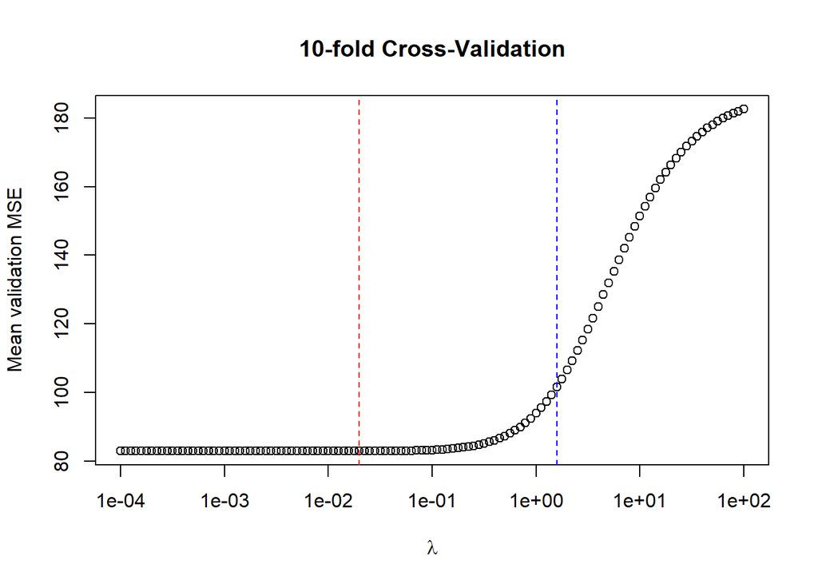

```r
plot(
  v[-1],
  mean_mse[-1],
  type = "b",
  log = "x",
  xlab = expression(lambda),
  ylab = "Mean validation MSE",
  main = "10-fold Cross-Validation"
)

points(
  0,
  mean_mse[1],
  pch = 19
)

abline(v = lambda_min, col = "red", lty = 2)
abline(v = lambda_1se, col = "blue", lty = 2)
```

2. Use all $n=332$ training observations to calculate the [lecture’s GCV criterion](https://teazrq.github.io/stat432rpy/topics/ridge-regression/optimization-and-cross-validation.html#loocv-and-gcv) for each $\lambda\in\Lambda$:

$$\operatorname{GCV}(\lambda)
=
\frac{
\operatorname{MSE}_{\mathrm{train}}(\lambda)
}{
\left\{
1-\operatorname{df}_{\mathrm{eff}}(\lambda)/n
\right\}^2
}.$$

Here $\operatorname{MSE}_{\mathrm{train}}$ is the training MSE, and $\operatorname{df}_{\mathrm{eff}}$ includes the unpenalized intercept, as in Question 3. Estimate means and scales once from all training observations and keep them fixed for this calculation. Plot the GCV curve and identify $\lambda_{\mathrm{GCV}}$.

**Show the workflow**

```r
x_mean = colMeans(X)

x_var = colMeans(
  (sweep(X, 2, x_mean, "-"))^2)

x_sd = sqrt(x_var)

X_std = sweep(X, 2, x_mean, "-")
X_std = sweep(X_std, 2, x_sd, "/")

y_mean = mean(Y)
Y_centered = Y - y_mean

gcv = numeric(length(v))
train_mse = numeric(length(v))
df_eff = numeric(length(v))

eigenvalues = eigen(
  t(X_std) %*% X_std,
  symmetric = TRUE,
  only.values = TRUE
)$values

for (l in seq_along(v)) {

  lambda = v[l]
  A = t(X_std) %*% X_std +
    n * lambda * diag(ncol(X_std))

  beta_hat = solve(A) %*%
    t(X_std) %*% Y_centered

  y_hat = y_mean + X_std %*% beta_hat

  train_mse[l] = mean((Y - y_hat)^2)

  df_eff[l] = 1 + sum(
    eigenvalues / (eigenvalues + n * lambda)
  )

  gcv[l] = train_mse[l] /
    (1 - df_eff[l] / n)^2
}
```

**Show the workflow**

```r
min_index = which.min(gcv)

lambda_GCV = v[min_index]

lambda_GCV
```

```
[1] 0.02818383
```

**Show the workflow**

```r
gcv[min_index]
```

```
[1] 83.50191
```

**Show the workflow**

```r
gcv_results = data.frame(
  lambda = v,
  train_MSE = train_mse,
  df_eff = df_eff,
  GCV = gcv
)

gcv_results
```

```
          lambda train_MSE   df_eff       GCV
1   0.000000e+00  80.09392 7.000000  83.58127
2   1.000000e-04  80.09392 6.998774  83.58064
3   1.122018e-04  80.09392 6.998625  83.58057
4   1.258925e-04  80.09392 6.998457  83.58048
5   1.412538e-04  80.09392 6.998269  83.58039
6   1.584893e-04  80.09392 6.998058  83.58028
7   1.778279e-04  80.09392 6.997821  83.58016
8   1.995262e-04  80.09392 6.997556  83.58002
9   2.238721e-04  80.09392 6.997258  83.57987
10  2.511886e-04  80.09393 6.996923  83.57970
11  2.818383e-04  80.09393 6.996548  83.57951
12  3.162278e-04  80.09393 6.996128  83.57929
13  3.548134e-04  80.09393 6.995656  83.57905
14  3.981072e-04  80.09394 6.995127  83.57879
```

[output cut: 108 more lines]

**Show the workflow**

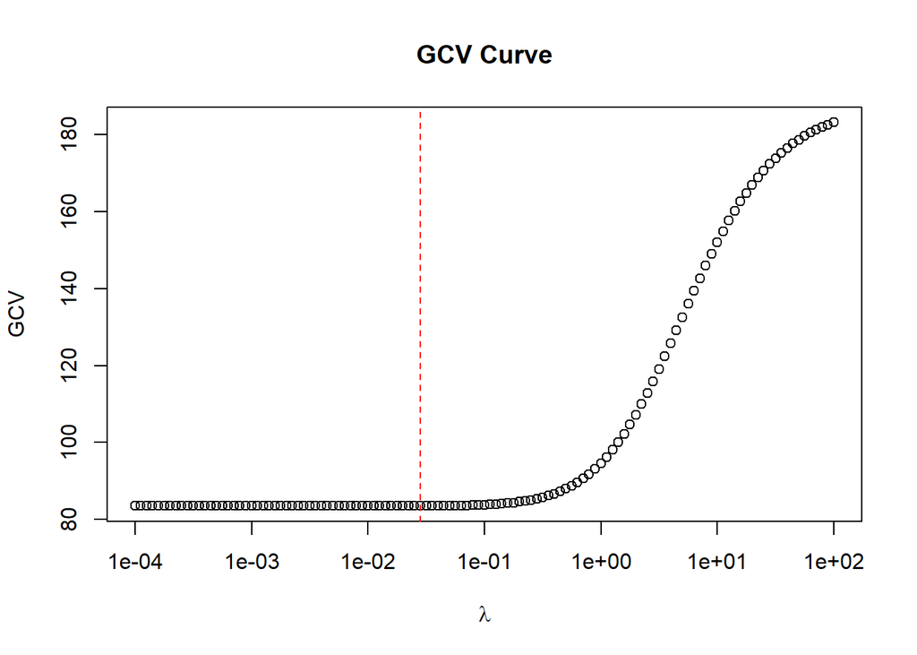

```r
plot(
  v[-1],
  gcv[-1],
  type = "b",
  log = "x",
  xlab = expression(lambda),
  ylab = "GCV",
  main = "GCV Curve"
)

# Add lambda = 0 separately
points(
  0,
  gcv[1],
  pch = 19
)

# Mark lambda_GCV
abline(
  v = lambda_GCV,
  col = "red",
  lty = 2
)
```

3. Fix all three choices before examining the test responses. Refit OLS and ridge at $\lambda_{\min}$, $\lambda_{\mathrm{1se}}$, and $\lambda_{\mathrm{GCV}}$ using all training observations. Report each model’s training MSE, test MSE, and effective degrees of freedom. Interpret the differences and explain why the model with the smallest observed test MSE must not be selected after viewing this table.

**Show the workflow**

```r
train = merge(df, df_split, by = "row_id") %>%
  filter(split == "train")

test = merge(df, df_split, by = "row_id") %>%
  filter(split == "test")

X_train = train %>%
  select(date, age, distance, stores, latitude, longitude) %>%
  as.matrix()

X_test = test %>%
  select(date, age, distance, stores, latitude, longitude) %>%
  as.matrix()

y_train = train %>% pull(price)
y_test = test %>% pull(price)

n = nrow(X_train)

# Training means
x_mean = colMeans(X_train)

# Training variances: divide by n
x_var = colMeans(
  (sweep(X_train, 2, x_mean, "-"))^2
)

x_sd = sqrt(x_var)

# Standardize training data
X_train_std = sweep(X_train, 2, x_mean, "-")
X_train_std = sweep(X_train_std, 2, x_sd, "/")

# Standardize test data using TRAINING means/scales
X_test_std = sweep(X_test, 2, x_mean, "-")
X_test_std = sweep(X_test_std, 2, x_sd, "/")

# Center training response
y_mean = mean(y_train)
y_train_centered = y_train - y_mean

lambda_choices = c(
  OLS = 0,
  lambda_min = lambda_min,
  lambda_1se = lambda_1se,
  lambda_GCV = lambda_GCV
)

lambda_choices
```

```
       OLS lambda_min lambda_1se lambda_GCV
0.00000000 0.01995262 1.58489319 0.02818383
```

**Show the workflow**

```r
results = data.frame(
  model = names(lambda_choices),
  lambda = as.numeric(lambda_choices),
  train_MSE = NA,
  test_MSE = NA,
  df_eff = NA
)

# Eigenvalues of X'X
eigenvalues = eigen(
  t(X_train_std) %*% X_train_std,
  symmetric = TRUE,
  only.values = TRUE
)$values


for (i in seq_along(lambda_choices)) {

  lambda = lambda_choices[i]

  # Ridge matrix
  A = t(X_train_std) %*% X_train_std +
    n * lambda * diag(ncol(X_train_std))

  # Fit coefficients
  beta_hat = solve(A) %*%
    t(X_train_std) %*% y_train_centered

  # Training predictions
  yhat_train = y_mean + X_train_std %*% beta_hat

  # Test predictions
  yhat_test = y_mean + X_test_std %*% beta_hat

  # Training MSE
  results$train_MSE[i] = mean(
    (y_train - yhat_train)^2
  )

  # Test MSE
  results$test_MSE[i] = mean(
    (y_test - yhat_test)^2
  )

  # Effective degrees of freedom
  results$df_eff[i] = 1 + sum(
    eigenvalues /
      (eigenvalues + n * lambda)
  )
}

results
```

```
       model     lambda train_MSE test_MSE   df_eff
1        OLS 0.00000000  80.09392 66.32246 7.000000
2 lambda_min 0.01995262  80.13543 65.99957 6.773213
3 lambda_1se 1.58489319 100.37356 81.19981 3.032870
4 lambda_GCV 0.02818383  80.17125 65.90276 6.688657
```

The model with the smallest observed test MSE must not be selected after viewing this table. The test set is reserved for final evaluation, so choosing the model that happens to perform best on it would use test responses to tune the model and make the reported performance optimistically biased. The model should instead be selected using the training folds or GCV, before the test responses are examined.

Solution:

We can’t look at the test results and then select the model with the smallest observed test MSE because it is only for final evaluation, and would be overly optimistic.

Strong shrinkage reduces degrees of freedom.

**TipStarter workflow**

After matching the two files by `row_id`, use this order:

```
for each validation fold:
    estimate predictor means and scales from the other nine folds
    for each lambda:
        fit on those nine folds and record validation MSE
summarize the ten fold errors and fix lambda_min and lambda_1se
compute GCV using all training observations and fix lambda_GCV
only then refit the four reported models and evaluate the test responses
```

## Reference

The real-estate data come from I-Cheng Yeh’s [Real Estate Valuation dataset](https://archive.ics.uci.edu/dataset/477/real%2Bestate%2Bvaluation%2Bda) in the UCI Machine Learning Repository. The distributed data retain the original observations and add only the course train-test and fold assignments.

## explain-to-me skill

```markdown
---
name: explain-to-me
description: A tool to help students understand the assigned homework questions by directing them to lecture materials, rewording the question, providing hints, etc. Employ this skill only when student asks to use it.
metadata:
  version: "1.0.0"
---

# Instructions

Read homework question from homework-03.qmd when prompted by student asking to use explain-to-me skill. Each homework assignment has 5-6 questions with multiple parts (1a, 1b, etc). Move onto the next learning tool if student responds and remains confused. First, clarify which part of the question is confusing to the student. Then, reword the question for ease of understanding. Next, provide a specific reference to lecture materials, found at https://teazrq.github.io/stat432rpy/topics/ridge-regression/ridge-regression.html and https://teazrq.github.io/stat432rpy/topics/ridge-regression/optimization-and-cross-validation.html. Additional lecture materials are linked at https://teazrq.github.io/stat432rpy/overview.html. Next, provide a brief example (from a different scenario) or outline of necessary steps, without providing the solution. Finally, provide a direct hint about how to begin with the first step.

# Rules

- Do not explicitly provide the solution to the question, unless prompted to do so.
- Do not delete, edit, or change code, and do not move or delete files.
- Do not use complicated jargon - explain at the level of an undergraduate student studying statistics with minimal background topics being covered.
- Do not provide feedback that contradicts the solutions, located at "solutions-03.qmd"
```